# Interaction in Regression

## Interaction

In some cases, the association between a predictor and the outcome may depend on a third variable, indicating an interaction term is needed. Consider a study of a drug designed to treat anxiety. Because of some gender differences in anxiety disorders, researchers have reason to wonder whether a new drug has the same effects in men and women.

## No Interaction

$$y_i = \beta_0 + \beta_1 \text{MALE}_i + \beta_2 \text{dose}_i +\varepsilon_i$$

## No Interaction

$$y_i = \beta_0 + \beta_1 \text{MALE}_i + \beta_2 \text{dose}_i +\varepsilon_i$$

In this model, $\text{MALE}_i$ takes value 0 for females and 1 for males. The variable $\text{dose}_i$ takes the numeric value of the dose in mg (0, 25, 50, or 75).

## No Interaction

$$y_i = \beta_0 + \beta_1 \text{MALE}_i + \beta_2 \text{dose}_i +\varepsilon_i$$

In this model, the expected anxiety levels at each dose are given below.

| Gender | Dose | Expected anxiety level |
| --- | --- | --- |
| Female | 0 | $\beta_0$ |
| Female | 25 | $\beta_0 + 25\beta_2$ |
| Female | 50 | $\beta_0 + 50\beta_2$ |
| Female | 75 | $\beta_0 + 75\beta_2$ |
| Male | 0 | $\beta_0+\beta_1$ |
| Male | 25 | $\beta_0+\beta_1+25\beta_2$ |
| Male | 50 | $\beta_0+\beta_1+50\beta_2$ |
| Male | 75 | $\beta_0+\beta_1+75\beta_2$ |

## Interaction

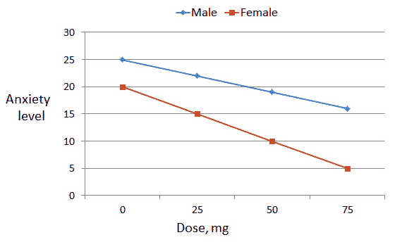

Here we have interaction between gender and dose – the drug appears to be more effective at reducing anxiety in women. There is also a “main effect” of gender (men have higher anxiety levels even at dose 0).

## Interaction

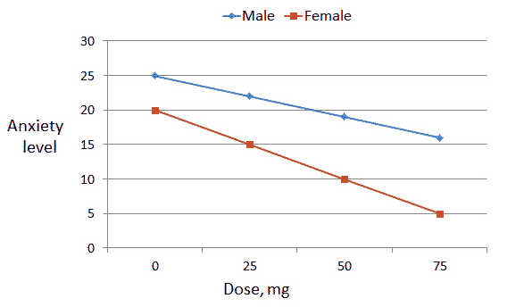

When we have an interaction in a model, the “effect” of one variable depends on the level of another. In this case, the dose effect of the drug is different for men and for women. The corresponding model would be similar to that below.

$$y_i = \beta_0 + \beta_1 \text{MALE}_i + \beta_2 \text{dose}_i + \beta_3\text{MALE}_i\text{dose}_i+\varepsilon_i$$

## Interaction

$$y_i = \beta_0 + \beta_1 \text{MALE}_i + \beta_2 \text{dose}_i + \beta_3\text{MALE}_i\text{dose}_i+\varepsilon_i$$

In this model, the expected anxiety levels at each dose are given below.

| Gender | Dose | Expected anxiety level |
| --- | --- | --- |
| Female | 0 | $\beta_0$ |
| Female | 25 | $\beta_0 + 25\beta_2$ |
| Female | 50 | $\beta_0 + 50\beta_2$ |
| Female | 75 | $\beta_0 + 75\beta_2$ |
| Male | 0 | $\beta_0+\beta_1$ |
| Male | 25 | $\beta_0+\beta_1+25(\beta_2+\beta_3)$ |
| Male | 50 | $\beta_0+\beta_1+50(\beta_2+\beta_3)$ |
| Male | 75 | $\beta_0+\beta_1+75(\beta_2+\beta_3)$ |

Let’s see if the gender-birth weight relationship is constant over gestational age.

$$y_i = \beta_0 + \beta_1 \text{GEST}_i + \beta_2 \text{male}_i + \beta_3 \text{GEST}_i\text{male_i}+\epsilon_i$$

- What is the slope for males? Females?
- How do you determine if gender is related to birth weight? If gestational age is related to birth weight?

## Interaction code

```r
o_data <- read.csv("~/Documents/TEACHING/vitalstats/Yr1117birth.csv",
  na.strings=c("9","99", "9999"))
#SEX=1 male, 2 female
o_data$SEX=factor(o_data$SEX, levels=c(1,2),labels=c("Male","Female"))

o_data$GEST_C=o_data$GEST; o_data$BWTG_C=o_data$BWTG
o_data$GEST_C[o_data$GEST_C>50]=NA
o_data$GEST_C[o_data$GEST_C<20]=NA
o_data$BWTG_C[o_data$BWTG_C<500]=NA
o_data$GEST_C[o_data$GEST_C<25 & o_data$BWTG_C>2000]=NA
# now center gestational age at typical value of 39 weeks
o_data$GEST_CENT=o_data$GEST_C-39
# unrealistically young and heavy - a sloppy fix and you can do better!
birth_data <- na.omit(o_data)
birth_data$SEX <- relevel(birth_data$SEX, ref = "Female")
#make females the referent group
```

```r
model2 = lm(BWTG_C~GEST_C+SEX+GEST_C*SEX, data=birth_data)
summary(model2)
```

```
##
## Call:
## lm(formula = BWTG_C ~ GEST_C + SEX + GEST_C * SEX, data = birth_data)
##
## Residuals:
##     Min      1Q  Median      3Q     Max
## -2954.7  -294.1   -18.9   270.9  4865.5
##
## Coefficients:
##                  Estimate Std. Error  t value Pr(>|t|)
## (Intercept)    -4099.1088    12.8184 -319.784  < 2e-16 ***
## GEST_C           189.3460     0.3318  570.628  < 2e-16 ***
## SEXMale          -83.6485    17.6648   -4.735 2.19e-06 ***
## GEST_C:SEXMale     5.4453     0.4576   11.900  < 2e-16 ***
## ---
## Signif. codes:  0 '***' 0.001 '**' 0.01 '*' 0.05 '.' 0.1 ' ' 1
##
## Residual standard error: 440.3 on 826956 degrees of freedom
## Multiple R-squared:  0.4661, Adjusted R-squared:  0.4661
## F-statistic: 2.406e+05 on 3 and 826956 DF,  p-value: < 2.2e-16
```

## Parameter Interpretation

This model is a little complicated to interpret – the intercept of -4099 represents the expected birth weight of a baby at 0 weeks of gestation (clear example of why we do not extrapolate outside the range of the data!). The main effect of gender tells us that male babies weigh less than females at 0 weeks of gestation (equally not useful, and also a good example of why we cannot extrapolate beyond the range of the data!).

Usually when we have complex terms like interactions or polynomials in a model, it’s easier to illustrate model results graphically.

## Graphical Interpretation

Let’s pull off the appropriate parameter estimates from the interaction model so we can plot the model-estimated lines for male and female infants.

```r
female_intercept <- model2$coefficients["(Intercept)"]
male_intercept <- model2$coefficients["(Intercept)"] +  model2$coefficients["SEXMale"]
female_slope <- model2$coefficients["GEST_C"]
male_slope <- model2$coefficients["GEST_C"] +  model2$coefficients["GEST_C:SEXMale"]
est2 <- data.frame(sl = c(female_slope,male_slope),
                 int = c(female_intercept,male_intercept),
                 SEX = c('Female','Male'))
est2
```

```
##         sl       int    SEX
## 1 189.3460 -4099.109 Female
## 2 194.7913 -4182.757   Male
```

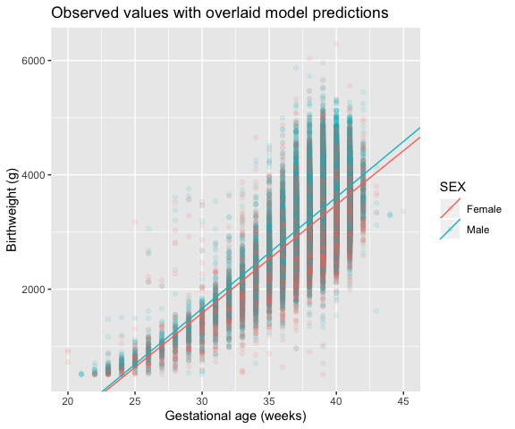

```r
# Plot some of the observed values and the predictions, sampling from original data
# (so ggplot doesn't run super slowly)
N <- 100000 # how many points from original data set to plot
birth_data_red <- birth_data[sample(1:nrow(birth_data),N),]
library(ggplot2)
# Note the bottom left -- we systematically under-predict for very young babies.
ggplot(birth_data_red, aes(x=GEST_C,y=BWTG_C,color=SEX)) + geom_point(alpha=0.1) +
  geom_abline(data=est2, aes(intercept=int, slope=sl, color=SEX)) +
  xlab("Gestational age (weeks)") + ylab("Birthweight (g)") +
  ggtitle("Observed values with overlaid model predictions")
```

## Centering

You might not like the big negative intercept in the previous model. One way to make the intercept have a realistic interpretation on its own is to use centered variables – for example we created a version of gestational age pseudo-centered 39 weeks. We’ll get the same plot but more interpretable estimates in a model using a centered predictor.

```r
model3 = lm(BWTG_C~GEST_CENT+SEX+GEST_CENT*SEX, data=birth_data)
summary(model3)
```

```
##
## Call:
## lm(formula = BWTG_C ~ GEST_CENT + SEX + GEST_CENT * SEX, data = birth_data)
##
## Residuals:
##     Min      1Q  Median      3Q     Max
## -2954.7  -294.1   -18.9   270.9  4865.5
##
## Coefficients:
##                    Estimate Std. Error t value Pr(>|t|)
## (Intercept)       3285.3866     0.7067  4648.8   <2e-16 ***
## GEST_CENT          189.3460     0.3318   570.6   <2e-16 ***
## SEXMale            128.7182     0.9906   129.9   <2e-16 ***
## GEST_CENT:SEXMale    5.4453     0.4576    11.9   <2e-16 ***
## ---
## Signif. codes:  0 '***' 0.001 '**' 0.01 '*' 0.05 '.' 0.1 ' ' 1
##
## Residual standard error: 440.3 on 826956 degrees of freedom
## Multiple R-squared:  0.4661, Adjusted R-squared:  0.4661
## F-statistic: 2.406e+05 on 3 and 826956 DF,  p-value: < 2.2e-16
```

This output is much easier to understand! The intercept now represents the expected birth weight at 39 weeks of a female infant.

```r
female_intercept3 <- model3$coefficients["(Intercept)"]
male_intercept3 <- model3$coefficients["(Intercept)"] +  model3$coefficients["SEXMale"]
female_slope3 <- model3$coefficients["GEST_CENT"]
male_slope3 <- model3$coefficients["GEST_CENT"] +  model3$coefficients["GEST_CENT:SEXMale"]
est3 <- data.frame(sl = c(female_slope3,male_slope3),
                 int = c(female_intercept3,male_intercept3),
                 SEX = c('Female','Male'))
est3
```

```
##         sl      int    SEX
## 1 189.3460 3285.387 Female
## 2 194.7913 3414.105   Male
```

Now you can easily see that at the typical (39 weeks) gestational age, the typical male baby is expected to weigh more than the typical female baby. Notice also the slopes are unaffected by the centering.

The estimates differ, but the plot and model fit are identical!

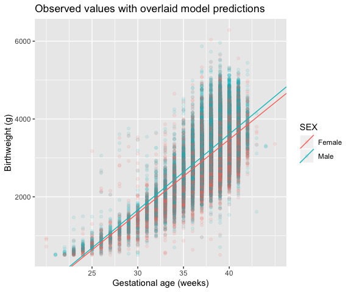

```r
# Sample from from original data (so ggplot doesn't run super slowly)
# note plot a bit trickier to create as need to translate axis scales to
# get labels on the original scale
ggplot(birth_data_red, aes(x=GEST_CENT,y=BWTG_C,color=SEX)) + geom_point(alpha=0.1) +
  geom_abline(data=est3, aes(intercept=int, slope=sl, color=SEX)) +
  labs(x=NULL)+
  scale_x_continuous(breaks=c(-14,-9,-4,1),labels=c("25","30","35","40"))+
  xlab("Gestational age (weeks)") + ylab("Birthweight (g)") +
  ggtitle("Observed values with overlaid model predictions")
```

## Class Exercise:

1. Fit the interaction model switching the referent group from females to males, and verify the slopes and intercepts are the same for females and males.
2. Fit a regression model with birth weight as the outcome and predictors including biological sex, total pregnancies (dichotomized as 1 or >1), smoking status (dichotomized as any versus none), and gestational age (linear term in weeks). Explore whether interaction or polynomial terms improve model fit.